# Data Patterns

### Load Data into R and transform to Time Series

First, set your working directory to wherever your excel file is, otherwise you’ll have to type in the complete file path.Also save your R project and your R script there.

[figure not shown]

Now you need to create an object and read the data from an excel file. If you typed the values from the book, type them as one series (one column). If you are using someone’s file, transform them to one column. You don’t need the years and quarters.Here is how my excel file looks after transforming:

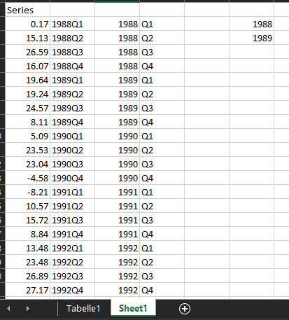

There are two tabs in the file and I concatenated the Year+Quarter. Now we want to import the data from Sheet1 to R.

```r
#For this, we use the package readxl and its function read_excel
#first, apply the function to the file
#create an object called firstdata0 and apply the function to it
#we have to specify the file name. This argument is a string, therefore use quotation marks ""
firstdata0 <- readxl::read_excel("first session.xlsx")
firstdata0
```

| Year | 1st | 2nd | 3rd | 4th | X__1 | X__2 | X__3 | X__4 | X__5 | X__6 | X__7 | X__8 | X__9 | X__10 | X__11 | X__12 | X__13 |
| --- | --- | --- | --- | --- | --- | --- | --- | --- | --- | --- | --- | --- | --- | --- | --- | --- | --- |
| 1988 | 0.17 | 15.13 | 26.59 | 16.07 | 1988Q1 | NA | NA | NA | NA | NA | NA | NA | NA | 1996 | 1997 | 1998 | 1999 |
| 1989 | 19.64 | 19.24 | 24.57 | 8.11 | 1988Q2 | NA | NA | NA | NA | NA | NA | NA | NA | NA | NA | NA | NA |
| 1990 | 5.09 | 23.53 | 23.04 | -4.58 | 1988Q3 | NA | NA | NA | NA | NA | NA | NA | NA | NA | NA | NA | NA |
| 1991 | -8.21 | 10.57 | 15.72 | 8.84 | 1988Q4 | NA | NA | NA | NA | NA | NA | NA | NA | NA | NA | NA | NA |
| 1992 | 13.48 | 23.48 | 26.89 | 27.17 | NA | NA | NA | NA | NA | NA | NA | NA | NA | NA | NA | NA | NA |
| 1993 | 24.93 | 42.15 | 48.83 | 38.37 | NA | NA | NA | NA | NA | NA | NA | NA | NA | NA | NA | NA | NA |
| 1994 | 41.85 | 58.52 | 58.62 | 20.34 | NA | NA | NA | NA | NA | NA | NA | NA | NA | NA | NA | NA | NA |
| 1995 | 11.83 | 59.72 | 67.72 | 43.36 | NA | NA | NA | NA | NA | NA | NA | NA | NA | NA | NA | NA | NA |
| 1996 | 33.00 | 85.32 | 60.86 | 28.16 | NA | NA | NA | NA | NA | NA | NA | NA | NA | NA | NA | NA | NA |
| 1997 | 50.87 | 93.83 | 92.51 | 80.55 | NA | NA | NA | NA | NA | NA | NA | NA | NA | NA | NA | NA | NA |

[output cut: 2 more lines]

Clearly that’s not what we want. Our goal is to get the time series in a friendly form.

```r
#remove firstdata0
remove(firstdata0)
#add some inputs to the function
#We additionally specify the file name, which sheet to take the data from, and the range. Why the range? I only want to get the first column.
firstdata <- readxl::read_excel("first session.xlsx", sheet='Sheet1', range = "A1:A48")
#this displays the first five entries
head(firstdata, n=5)
```

| Series |
| --- |
| 0.17 |
| 15.13 |
| 26.59 |
| 16.07 |
| 19.64 |

Now the data is loaded into R. Let’s check what object type we have

```r
str(firstdata)
```

```
Classes ‘tbl_df’, ‘tbl’ and 'data.frame':   47 obs. of  1 variable:
 $ Series: num  0.17 15.13 26.59 16.07 19.64 ...
```

This is a data frame. We however want a timeseries because then we can use a number of specific functions.

```r
#to make a time series, create a new object and apply the ts function to it like this:
series <- ts(firstdata$Series, frequency=4, start=1988)
#as you can see, we defined the frequency of observations as 4 per year and the starting year as 1988.
#let's display the object
series
```

```
       Qtr1   Qtr2   Qtr3   Qtr4
1988   0.17  15.13  26.59  16.07
1989  19.64  19.24  24.57   8.11
1990   5.09  23.53  23.04  -4.58
1991  -8.21  10.57  15.72   8.84
1992  13.48  23.48  26.89  27.17
1993  24.93  42.15  48.83  38.37
1994  41.85  58.52  58.62  20.34
1995  11.83  59.72  67.72  43.36
1996  33.00  85.32  60.86  28.16
1997  50.87  93.83  92.51  80.55
1998  70.01 133.39 129.64 100.38
1999  95.85 157.76 126.98
```

Let’s plot a series (standard series of R-base).

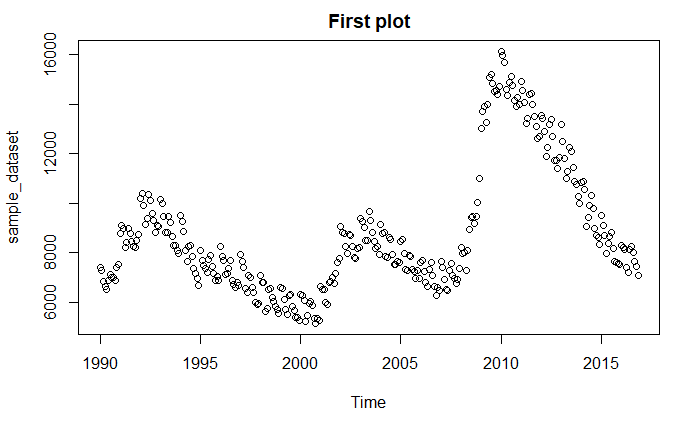

```r
#we use a generic plot function, there are many more.
#we use type = "p" for points in the scatterplot. Other types are available, use Help in Rstudio(F1) to find out more.
#main is the title of the plot
library(seasonal)
sample_dataset <- unemp
plot(sample_dataset, type="p",main="First plot")
```

### Autocorrelation

To do this, we use the acf function from the stats package, which is pre-loaded.

```r
# Load packages
library(zoo)
library(forecast)
# We specify the series, then we want to first look at the ACF, then we want to see it plotted. All until lag 10. Coredata is used to extract the timeseries plainly.
acf(coredata(sample_dataset), plot=FALSE, lag.max =10)
```

```
Autocorrelations of series ‘coredata(sample_dataset)’, by lag

    0     1     2     3     4     5     6     7     8     9    10
1.000 0.976 0.947 0.928 0.927 0.930 0.919 0.898 0.865 0.835 0.824
```

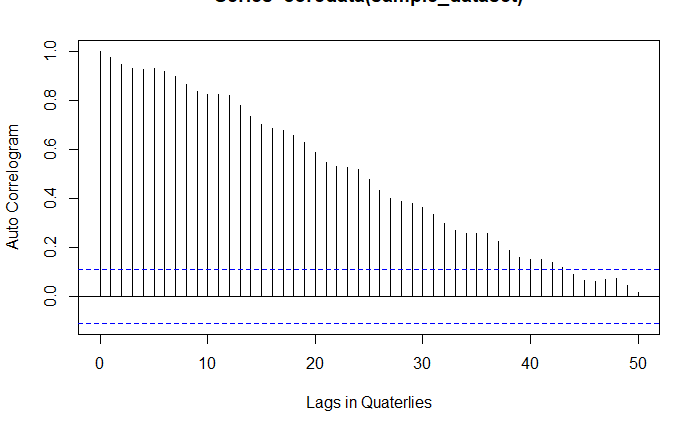

```r
acf(coredata(sample_dataset), plot=TRUE, lag.max=50, xlim=c(0,50), ylab="Auto Correlogram", xlab="Lags in Quaterlies")
```

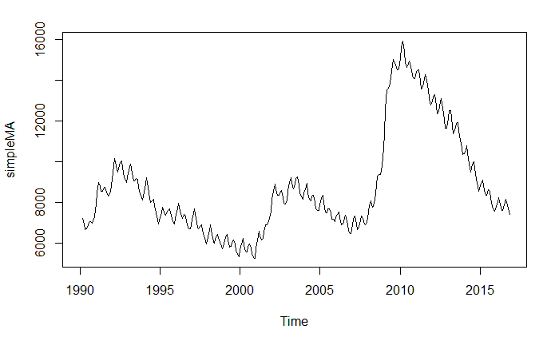

```r
library(TTR)
simpleMA <- SMA(sample_dataset, n=3)
plot.ts(simpleMA)
```

For decomposition of your forecast, it is important to analyse the seasonality, trend and randomness of your historic data. This can easily be done in R by calling the decompose function.

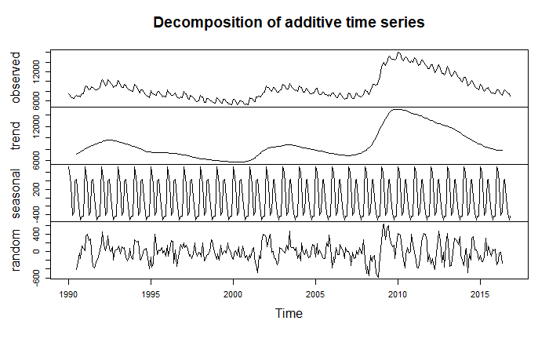

```r
decomposition_of_historic_data <- decompose(sample_dataset)
plot(decomposition_of_historic_data)
```

```r
exp <- HoltWinters(sample_dataset, beta = 0, gamma = 0)
exp_seasonal <- HoltWinters(sample_dataset, gamma = 0)
exp_seasonal_trend <- HoltWinters(sample_dataset)
print(exp)
```

```
Holt-Winters exponential smoothing with trend and additive seasonal component.

Call:
HoltWinters(x = sample_dataset, beta = 0, gamma = 0)

Smoothing parameters:
 alpha: 0.9999498
 beta : 0
 gamma: 0

Coefficients:
          [,1]
a   7437.15162
b    137.37602
s1  -409.19097
s2   696.01736
s3   901.43403
s4   663.01736
s5  -214.60764
s6  -107.19097
s7   352.80903
s8   -29.10764
s9  -291.39931
s10 -461.73264
s11 -728.94097
s12 -371.10764
```

```r
predictions <- exp$fitted
head(predictions)
```

```
             xhat    level   trend    season
Jan 1991 7837.925 7004.532 137.376  696.0174
Feb 1991 9129.745 8090.935 137.376  901.4340
Mar 1991 9019.960 8219.566 137.376  663.0174
Apr 1991 8254.752 8331.984 137.376 -214.6076
May 1991 8470.794 8440.609 137.376 -107.1910
Jun 1991 9032.378 8542.193 137.376  352.8090
```

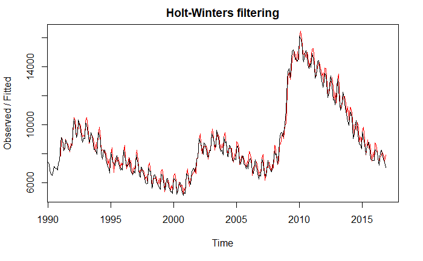

```r
plot(exp)
```

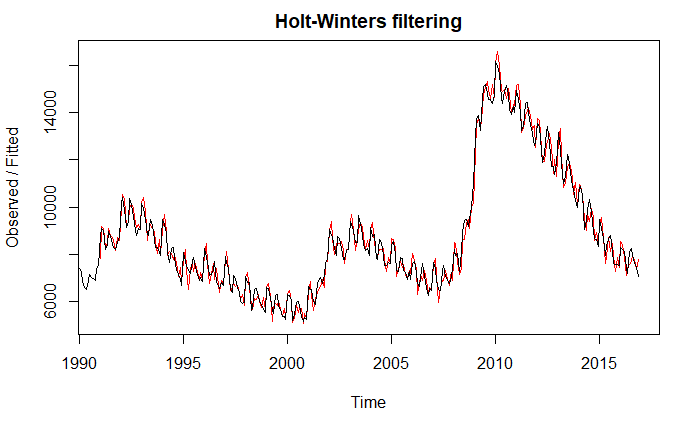

```r
plot(exp_seasonal)
```

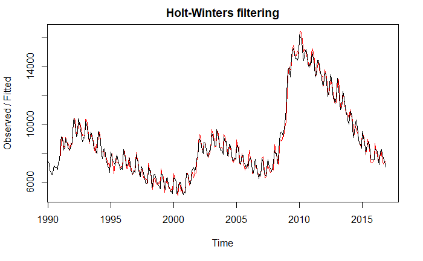

```r
plot(exp_seasonal_trend)
```

```r
cat("SSE exp", exp$SSE, "\n", "SSE exp Seasonality", exp_seasonal$SSE, "\n", "SSE exp Seasonality and Trend", exp_seasonal_trend$SSE, "\n")
```

```
SSE exp 41957605
 SSE exp Seasonality 35865368
 SSE exp Seasonality and Trend 25231887
```

```r
n <- length(exp$fitted)
m <- length(exp$coefficients)
v <- n - m
cat("With this formula we have established the values for n and m, those being", n, "and", m, "therefore we can calculate v by substraction.", "V is", v)
```

```
With this formula we have established the values for n and m, those being 1244 and 14 therefore we can calculate v by substraction. V is 1230
```

```r
# Calculate MSE
MSE <- exp$SSE / v
cat("MSE =", MSE)
```

```
MSE = 34111.87
```

In order to forecast the data for hundred periods, one can use the forecast package. The syntax works as follows:

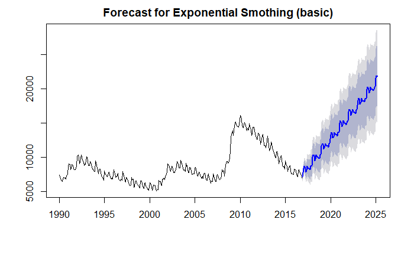

```r
exp_fore <- forecast::forecast(exp, h = 100)
exp_fore_trend_seasonal <- forecast::forecast(exp_seasonal_trend, h = 100)
plot(exp_fore, main="Forecast for Exponential Smothing (basic)")
```

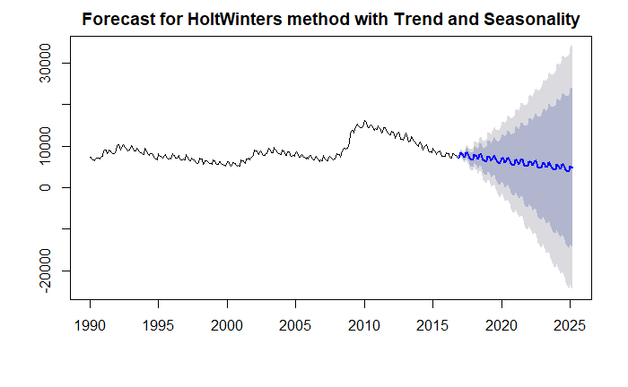

```r
plot(exp_fore_trend_seasonal, main = "Forecast for HoltWinters method with Trend and Seasonality")
```

### Linear Regression

In order to a linear regression, one needs to call the lm function. The syntax of the function is written as follows: dependent_variable ~ independent_variable_1 + independent_variable_2 + independent_variable_3. The object creates should be stored somewhere and specifics can be plotted too. For this case the dataset Iris is used. The summary function gives an overview of all the attributes of the model.

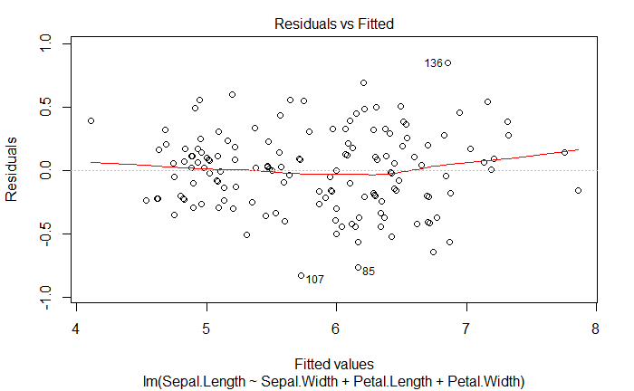

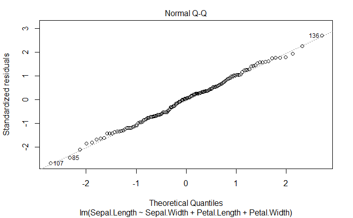

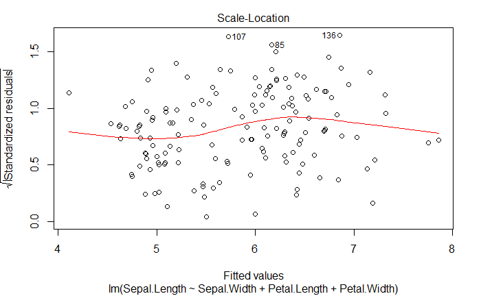

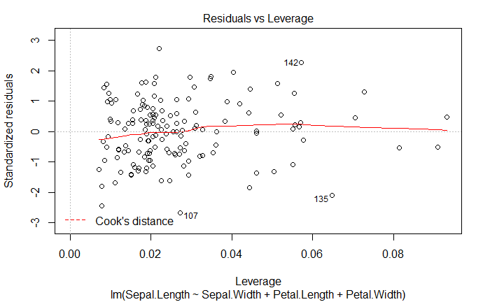

```r
linear_reg <- lm(Sepal.Length ~ Sepal.Width + Petal.Length + Petal.Width, data=iris)
plot(linear_reg)
```

```r
summary(linear_reg)
```

```
Call:
lm(formula = Sepal.Length ~ Sepal.Width + Petal.Length + Petal.Width,
    data = iris)

Residuals:
     Min       1Q   Median       3Q      Max
-0.82816 -0.21989  0.01875  0.19709  0.84570

Coefficients:
             Estimate Std. Error t value Pr(>|t|)
(Intercept)   1.85600    0.25078   7.401 9.85e-12 ***
Sepal.Width   0.65084    0.06665   9.765  < 2e-16 ***
Petal.Length  0.70913    0.05672  12.502  < 2e-16 ***
Petal.Width  -0.55648    0.12755  -4.363 2.41e-05 ***
---
Signif. codes:  0 ‘***’ 0.001 ‘**’ 0.01 ‘*’ 0.05 ‘.’ 0.1 ‘ ’ 1

Residual standard error: 0.3145 on 146 degrees of freedom
Multiple R-squared:  0.8586,    Adjusted R-squared:  0.8557
F-statistic: 295.5 on 3 and 146 DF,  p-value: < 2.2e-16
```

Delayed regression

```r
delayed_regression <- lm(sample_dataset ~ lag(sample_dataset, k=10), data=sample_dataset)
summary(delayed_regression)
```

```
essentially perfect fit: summary may be unreliable
```

```
Call:
lm(formula = sample_dataset ~ lag(sample_dataset, k = 10), data = sample_dataset)

Residuals:
       Min         1Q     Median         3Q        Max
-1.800e-12 -1.425e-13 -9.120e-14 -1.580e-14  2.612e-11

Coefficients:
                             Estimate Std. Error   t value Pr(>|t|)
(Intercept)                 3.239e-12  2.949e-13 1.098e+01   <2e-16 ***
lag(sample_dataset, k = 10) 1.000e+00  3.231e-17 3.095e+16   <2e-16 ***
---
Signif. codes:  0 ‘***’ 0.001 ‘**’ 0.01 ‘*’ 0.05 ‘.’ 0.1 ‘ ’ 1

Residual standard error: 1.474e-12 on 321 degrees of freedom
Multiple R-squared:      1, Adjusted R-squared:      1
F-statistic: 9.579e+32 on 1 and 321 DF,  p-value: < 2.2e-16
```

```r
library(lmtest)
library(car)
# Durbin-Watson test
cat("Durbin Watson test", "\n")
```

```
Durbin Watson test
```

```r
dwtest(delayed_regression)
```

```
    Durbin-Watson test

data:  delayed_regression
DW = 2.1361, p-value = 0.8794
alternative hypothesis: true autocorrelation is greater than 0
```

```r
cat("VIF:", vif(linear_reg), "\n")
```

```
VIF: 1.270815 15.09757 14.23433
```

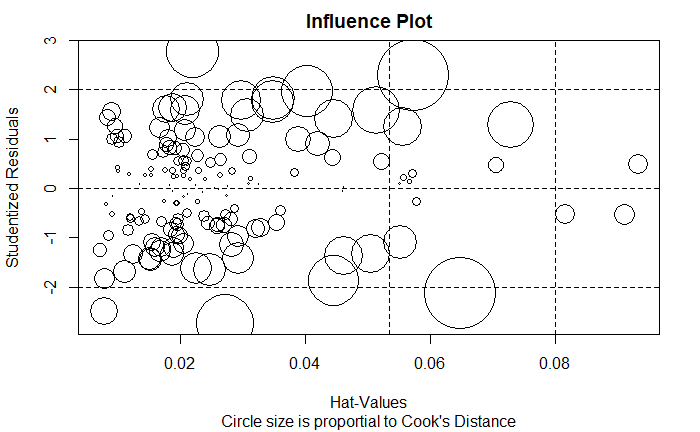

```r
# Starmap
influencePlot(linear_reg,   id.method="identify", main="Influence Plot", sub="Circle size is proportial to Cook's Distance" )
```